# UC00180_AI_Pedestrian_Flow_Prediction

AI Pedestrian Flow Prediction

**Authored by: Adithya Sentil**

**Duration:** 90 mins

**Level:** Intermediate

**Pre-requisite Skills:** Python

## Scenario

The City of Melbourne experiences significant variations in pedestrian movement due to changing weather conditions, scheduled public events, and daily activity patterns. During large-scale events (e.g. F1 or AFL games), certain areas become heavily congested, while others remain underutilised. This makes it difficult for city planners and safety personnel to anticipate foot traffic and allocate resources efficiently.

To combat this I propose a predictive AI model that forecasts pedestrian flow across various sensors in the city using historical pedestrian count data, scheduled event data, event locations, and weather conditions. The outcome will help optimise public safety planning, infrastructure usage, and event coordination.

### User Story

**As** a city data scientist at the City of Melbourne,  
**I want** to use an AI model that can accurately predict pedestrian flow patterns based on historical pedestrian sensor data, weather conditions, and scheduled event data,  
**so that** I can provide insights to city planners and emergency services to proactively manage pedestrian movement and reduce overcrowding during high-traffic events.

## Introduction

Understanding pedestrian movement patterns is essential for enhancing city planning, improving public safety, and ensuring smooth mobility during both regular days and large-scale events. The City of Melbourne collects a vast amount of data from pedestrian sensors located across the city, which, when combined with contextual data such as weather conditions and event schedules, can provide valuable insights into human mobility.

This project focuses on developing an AI-based model that utilises the datasets to accurately predict pedestrian flow. By predicting movement trends, the city can proactively manage crowds, allocate resources efficiently, and optimise infrastructure usage. This approach not only supports safer and more efficient urban environments but also contributes to a smarter, data-driven city management strategy.

***Dataset Links***

- Pedestrian counting link: https://data.melbourne.vic.gov.au/explore/dataset/pedestrian-counting-system-monthly-counts-per-hour/api/
- Venue location data link: https://data.melbourne.vic.gov.au/explore/dataset/venues-for-event-bookings/api/
- Weather station data link: https://data.melbourne.vic.gov.au/explore/dataset/meshed-sensor-type-1/information/

### Importing Required Libraries

```python
import numpy as np
import pandas as pd
import seaborn as sns
import matplotlib.pyplot as plt
import requests
import os
import requests
from functools import reduce
```

## Importing Datasets

To build the AI-based pedestrian flow prediction model, we begin by importing the relevant datasets from the City of Melbourne Open Data API. The following datasets are used in this project:

- **Pedestrian Counting System**: Hourly pedestrian counts from sensors installed across the city.
- **Event Locations**: Data on the locations and timings of public events in Melbourne.
- **Weather Data**: Historical weather conditions including temperature, rainfall, and wind.

These datasets are accessed using API requests and loaded into pandas DataFrames for preprocessing and analysis.

```python
def fetch_data(base_url, dataset, api_key, num_records=99, offset=0):
    all_records = []
    max_offset = 9900  # Maximum number of requests

    while True:
        # Maximum limit check
        if offset > max_offset:
            break

        # Create API request URL
        filters = f'{dataset}/records?limit={num_records}&offset={offset}'
        url = f'{base_url}{filters}&api_key={api_key}'

        # Start request
        try:
            result = requests.get(url, timeout=10)
            result.raise_for_status()
            records = result.json().get('results')
        except requests.exceptions.RequestException as e:
            raise Exception(f"API request failed: {e}")
        if records is None:
            break
        all_records.extend(records)
        if len(records) < num_records:
            break

        # Next cycle offset
        offset += num_records

    # DataFrame all data
    df = pd.DataFrame(all_records)
    return df

#os.environ.get('MELBOURNE_API_KEY')

# Retrieve API key from environment variable

BASE_URL = 'https://data.melbourne.vic.gov.au/api/explore/v2.1/catalog/datasets/'
```

### Importing Pedestrian Count Data

```python
# Data set name
dataset_pedestrian_counting = 'pedestrian-counting-system-monthly-counts-per-hour'
# Fetch dataset
pedestrian_counting = fetch_data(BASE_URL, dataset_pedestrian_counting, API_KEY)
# Create a new row named latitude
pedestrian_counting['latitude'] = pedestrian_counting['location'].apply(lambda x: x['lat'] if isinstance(x, dict) else None)
# Create a new row named longitude
pedestrian_counting['longitude'] = pedestrian_counting['location'].apply(lambda x: x['lon'] if isinstance(x, dict) else None)

pedestrian_counting.head()
```

|  | id | location_id | sensing_date | hourday | direction_1 | direction_2 | pedestriancount | sensor_name | location | latitude | longitude |
| --- | --- | --- | --- | --- | --- | --- | --- | --- | --- | --- | --- |
| 0 | 862320241010 | 86 | 2024-10-10 | 23 | 0 | 5 | 5 | 574Qub_T | {'lon': 144.94908064, 'lat': -37.80309992} | -37.803100 | 144.949081 |
| 1 | 862020241223 | 86 | 2024-12-23 | 20 | 13 | 31 | 44 | 574Qub_T | {'lon': 144.94908064, 'lat': -37.80309992} | -37.803100 | 144.949081 |
| 2 | 24020240611 | 24 | 2024-06-11 | 0 | 47 | 50 | 97 | Col620_T | {'lon': 144.95449198, 'lat': -37.81887963} | -37.818880 | 144.954492 |
| 3 | 72120250705 | 72 | 2025-07-05 | 1 | 3 | 28 | 31 | ACMI_T | {'lon': 144.96872809, 'lat': -37.81726338} | -37.817263 | 144.968728 |
| 4 | 10720250707 | 10 | 2025-07-07 | 7 | 22 | 74 | 96 | BouHbr_T | {'lon': 144.94710545, 'lat': -37.81876474} | -37.818765 | 144.947105 |

### Importing Weather Data

```python
# Data set name
weather_stations = 'meshed-sensor-type-1'
# Fetch dataset
weather_stations_df = fetch_data(BASE_URL, weather_stations, API_KEY)


weather_stations_df.head()
```

|  | device_id | time | rtc | battery | solarpanel | command | solar | precipitation | strikes | windspeed | winddirection | gustspeed | vapourpressure | atmosphericpressure | relativehumidity | airtemp | lat_long | sensor_name |
| --- | --- | --- | --- | --- | --- | --- | --- | --- | --- | --- | --- | --- | --- | --- | --- | --- | --- | --- |
| 0 | atmos41-32fc | 2025-08-16T20:40:34+00:00 | 121366929 | 4.140 | 1.458 | 0 | 0 | 0 | 0 | 1.38 | 174.9 | 2.11 | 0.74 | 101.18 | 86 | 4.8 | None | None |
| 1 | atmos41-32fc | 2025-08-16T21:10:53+00:00 | 121368748 | 4.137 | 19.340 | 0 | 3 | 0 | 0 | 1.55 | 170.9 | 2.32 | 0.73 | 101.22 | 86 | 4.6 | None | None |
| 2 | atmos41-32fc | 2025-08-16T20:10:00+00:00 | 121365095 | 4.140 | 0.225 | 0 | 0 | 0 | 0 | 1.52 | 171.7 | 2.44 | 0.74 | 101.16 | 86 | 4.8 | None | None |
| 3 | atmos41-32fc | 2025-08-17T00:11:54+00:00 | 121379609 | 4.208 | 22.161 | 0 | 140 | 0 | 0 | 1.05 | 155.4 | 2.67 | 0.91 | 101.33 | 83 | 8.3 | None | None |
| 4 | atmos41-32fc | 2025-08-17T02:26:30+00:00 | 121387685 | 4.209 | 22.064 | 0 | 175 | 0 | 0 | 0.89 | 152.1 | 2.80 | 1.01 | 101.32 | 67 | 13.2 | None | None |

### Importing Venue Location Data

```python
venue_location = fetch_data(BASE_URL, 'venues-for-event-bookings', API_KEY)
# Create a new row named latitude
venue_location['latitude'] = venue_location['geo_point_2d'].apply(lambda x: x['lat'] if isinstance(x, dict) else None)
# Create a new row named longitude
venue_location['longitude'] = venue_location['geo_point_2d'].apply(lambda x: x['lon'] if isinstance(x, dict) else None)
venue_location.head()
```

|  | geo_point_2d | geo_shape | prop_id | no_smoking | level_1_na | addresspt1 | event | full_name | addressp_1 | training | ... | sport | promotion | bookable | level_3_na | wedding | roadseg_id | sustainabi | level_2_na | latitude | longitude |
| --- | --- | --- | --- | --- | --- | --- | --- | --- | --- | --- | --- | --- | --- | --- | --- | --- | --- | --- | --- | --- | --- |
| 0 | {'lon': 144.98896595113547, 'lat': -37.8171274... | {'type': 'Feature', 'geometry': {'coordinates'... | 0 | N | Other Park Locations | 29.98397741 | Y | Other Park Locations: Weedon Reserve | 77 | N | ... | None | None | Y | None | N | 21951 | L | Weedon Reserve | -37.817127 | 144.988966 |
| 1 | {'lon': 144.98293613155118, 'lat': -37.8425742... | {'type': 'Feature', 'geometry': {'coordinates'... | 103756 | N | Fawkner Park | 0.0 | N | Fawkner Park: FP - Cordner_T1_T2_T3_F2_Ct3 | 0 | N | ... | Y | None | Y | None | N | 0 | M | FP - Cordner_T1_T2_T3_F2_Ct3 | -37.842574 | 144.982936 |
| 2 | {'lon': 144.9554621837315, 'lat': -37.78557214... | {'type': 'Feature', 'geometry': {'coordinates'... | 107426 | N | Royal Park | 0.0 | N | Royal Park: RP - Lawn 6_Walker East_Ct2 | 0 | N | ... | Y | None | Y | None | N | 0 | L | RP - Lawn 6_Walker East_Ct2 | -37.785572 | 144.955462 |
| 3 | {'lon': 144.98286097598913, 'lat': -37.8445902... | {'type': 'Feature', 'geometry': {'coordinates'... | 103756 | N | Fawkner Park | 0.0 | Y | Fawkner Park: FP - Lawn 21_T8_S3 | 0 | Y | ... | Y | None | Y | None | N | 0 | M | FP - Lawn 21_T8_S3 | -37.844590 | 144.982861 |
| 4 | {'lon': 144.97660241098285, 'lat': -37.8246014... | {'type': 'Feature', 'geometry': {'coordinates'... | 108615 | N | Kings Domain | 0.0 | Y | Kings Domain: KD - Lawn 9/Pillars of Wisdom | 0 | Y | ... | None | None | Y | None | Y | 0 | M | KD - Lawn 9/Pillars of Wisdom | -37.824601 | 144.976602 |

5 rows × 24 columns

## Cleaning Datasets

Once the datasets are imported, the next step is to clean and prepare the data for analysis. This involves the following tasks:

- **Handling Missing Values**: Identifying and filling or removing missing or null entries to ensure consistency.
- **Parsing Date and Time**: Converting date and time columns into proper datetime formats for easier merging and time-based analysis.
- **Extracting Relevant Columns**: Dropping irrelevant or redundant columns and keeping only the necessary features.
- **Standardising Column Names**: Renaming columns for consistency across datasets.
- **Filtering by Location or Date**: Limiting data to specific sensors, areas, or timeframes relevant to the prediction task.

Clean and well-structured data ensures accurate model training and better predictive performance.

#### Data Quality and Summary Statistics Overview Pedestrian Count Data

1. **Missing data Check**
   - I check the total number of missing data within each column with the sue of `.isnull().sum()`, this will indicate if there is missing data and which column does have it.
2. **Statistical Description**
   - To obtain a statistical summary I use the `.describe()` method. This will aid in understanding the distribution of the data and will point out any annomailies.
3. **Data Structure Summary**
   - To obtain a statistical overview of the dataset and find outliers it is useful to implement `.info()`

```python
print("Check for missing information in each column")
print(pedestrian_counting.isnull().sum())
print("Statistical Description")
print(pedestrian_counting.describe())
print("Data Structure Summary")
print(pedestrian_counting.info())
```

```
Check for missing information in each column
id                 0
location_id        0
sensing_date       0
hourday            0
direction_1        0
direction_2        0
pedestriancount    0
sensor_name        0
location           0
latitude           0
longitude          0
dtype: int64
Statistical Description
                 id  location_id      hourday  direction_1  direction_2  \
count  9.999000e+03  9999.000000  9999.000000  9999.000000  9999.000000
mean   4.575143e+11    68.522652    11.856286   192.428243   194.903390
std    4.813402e+11    46.616129     6.731115   295.791198   305.159582
min    1.020240e+09     1.000000     0.000000     0.000000     0.000000
25%    6.762025e+10    30.000000     6.000000    19.000000    20.000000
50%    2.519202e+11    58.000000    12.000000    84.000000    82.000000
75%    7.015203e+11   107.000000    18.000000   229.000000   236.500000
max    1.851920e+12   185.000000    23.000000  4930.000000  5589.000000

       pedestriancount     latitude    longitude
count      9999.000000  9999.000000  9999.000000
mean        387.331633   -37.813151   144.960284
std         567.258374     0.006659     0.009135
min           0.000000   -37.825910   144.929734
25%          40.000000   -37.817940   144.954492
50%         172.000000   -37.814141   144.962997
75%         485.000000   -37.809993   144.966589
max        5926.000000   -37.794324   144.974677
Data Structure Summary
<class 'pandas.core.frame.DataFrame'>
RangeIndex: 9999 entries, 0 to 9998
Data columns (total 11 columns):
 #   Column           Non-Null Count  Dtype
---  ------           --------------  -----
 0   id               9999 non-null   int64
 1   location_id      9999 non-null   int64
 2   sensing_date     9999 non-null   object
 3   hourday          9999 non-null   int64
 4   direction_1      9999 non-null   int64
 5   direction_2      9999 non-null   int64
 6   pedestriancount  9999 non-null   int64
 7   sensor_name      9999 non-null   object
 8   location         9999 non-null   object
 9   latitude         9999 non-null   float64
 10  longitude        9999 non-null   float64
dtypes: float64(2), int64(6), object(3)
memory usage: 859.4+ KB
None
```

```python
pedestrian_counting.drop(columns=['id', 'sensor_name', 'location'], inplace=True)
pedestrian_counting.head()
```

|  | location_id | sensing_date | hourday | direction_1 | direction_2 | pedestriancount | latitude | longitude |
| --- | --- | --- | --- | --- | --- | --- | --- | --- |
| 0 | 86 | 2024-10-10 | 23 | 0 | 5 | 5 | -37.803100 | 144.949081 |
| 1 | 86 | 2024-12-23 | 20 | 13 | 31 | 44 | -37.803100 | 144.949081 |
| 2 | 24 | 2024-06-11 | 0 | 47 | 50 | 97 | -37.818880 | 144.954492 |
| 3 | 72 | 2025-07-05 | 1 | 3 | 28 | 31 | -37.817263 | 144.968728 |
| 4 | 10 | 2025-07-07 | 7 | 22 | 74 | 96 | -37.818765 | 144.947105 |

```python
#updating sensing date data to uniform across all datasets
pedestrian_counting['sensing_date']= pd.to_datetime(pedestrian_counting['sensing_date'])
#create a new time col date_time, and combine sensing_date and hourday
pedestrian_counting['date_time'] = pedestrian_counting['sensing_date'] + pd.to_timedelta(pedestrian_counting['hourday'], unit= 'h')
pedestrian_counting.head()
```

|  | location_id | sensing_date | hourday | direction_1 | direction_2 | pedestriancount | latitude | longitude | date_time |
| --- | --- | --- | --- | --- | --- | --- | --- | --- | --- |
| 0 | 86 | 2024-10-10 | 23 | 0 | 5 | 5 | -37.803100 | 144.949081 | 2024-10-10 23:00:00 |
| 1 | 86 | 2024-12-23 | 20 | 13 | 31 | 44 | -37.803100 | 144.949081 | 2024-12-23 20:00:00 |
| 2 | 24 | 2024-06-11 | 0 | 47 | 50 | 97 | -37.818880 | 144.954492 | 2024-06-11 00:00:00 |
| 3 | 72 | 2025-07-05 | 1 | 3 | 28 | 31 | -37.817263 | 144.968728 | 2025-07-05 01:00:00 |
| 4 | 10 | 2025-07-07 | 7 | 22 | 74 | 96 | -37.818765 | 144.947105 | 2025-07-07 07:00:00 |

### Visualising Pedestrian Count

Bar plot that indicates the total pedestrian count by hour, this will allow us to identify the peak foot traffic hours across the city.

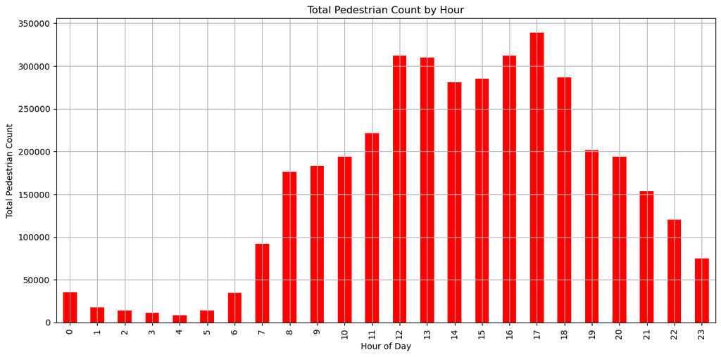

```python
# Group by hour and sum pedestrian counts
hourly_counts = pedestrian_counting.groupby('hourday')['pedestriancount'].sum()

# Plot the grouped data
plt.figure(figsize=(12, 6))
hourly_counts.plot(kind='bar', color='red')

# Add titles and labels
plt.title('Total Pedestrian Count by Hour')
plt.xlabel('Hour of Day')
plt.ylabel('Total Pedestrian Count')
plt.grid(True)
plt.tight_layout()
plt.show()
```

#### Data Quality and Summary Statistics Overview Weather data

1. **Missing data Check**
   - I check the total number of missing data within each column with the sue of `.isnull().sum()`, this will indicate if there is missing data and which column does have it.
2. **Statistical Description**
   - To obtain a statistical summary I use the `.describe()` method. This will aid in understanding the distribution of the data and will point out any annomailies.
3. **Data Structure Summary**
   - To obtain a statistical overview of the dataset and find outliers it is useful to implement `.info()`

```python
print("Check for missing information in each column")
print(weather_stations_df .isnull().sum())
print("Statistical Description")
print(weather_stations_df .describe())
print("Data Structure Summary")
print(weather_stations_df .info())
```

```
Check for missing information in each column
device_id                 0
time                      0
rtc                       0
battery                   0
solarpanel                0
command                   0
solar                     0
precipitation             0
strikes                   0
windspeed                 0
winddirection             0
gustspeed                 0
vapourpressure            0
atmosphericpressure       0
relativehumidity          0
airtemp                   0
lat_long               9999
sensor_name            9999
dtype: int64
Statistical Description
                rtc      battery   solarpanel  command        solar  \
count  9.999000e+03  9999.000000  9999.000000   9999.0  9999.000000
mean   9.354407e+07     4.180553    10.578352      0.0   114.418142
std    1.671959e+07     0.025408    10.102549      0.0   198.805517
min    5.862781e+06     4.128000     0.000000      0.0     0.000000
25%    8.360097e+07     4.158000     0.233000      0.0     0.000000
50%    9.495296e+07     4.181000    11.596000      0.0     2.000000
75%    1.061945e+08     4.208000    21.411000      0.0   142.500000
max    1.213912e+08     4.232000    23.724000      0.0   970.000000

       precipitation      strikes    windspeed  winddirection    gustspeed  \
count         9999.0  9999.000000  9999.000000    9999.000000  9999.000000
mean             0.0     0.007401    -1.951308     156.042764    -0.297152
std              0.0     0.433108   173.197879     182.993800   173.232029
min              0.0     0.000000 -9999.000000   -9999.000000 -9999.000000
25%              0.0     0.000000     0.710000     144.600000     1.620000
50%              0.0     0.000000     0.960000     170.300000     2.410000
75%              0.0     0.000000     1.290000     183.600000     3.470000
max              0.0    42.000000     3.480000     359.900000    13.570000
```

[output cut: 22 more lines]

```
 6   solar                9999 non-null   int64
 7   precipitation        9999 non-null   int64
 8   strikes              9999 non-null   int64
 9   windspeed            9999 non-null   float64
 10  winddirection        9999 non-null   float64
 11  gustspeed            9999 non-null   float64
 12  vapourpressure       9999 non-null   float64
 13  atmosphericpressure  9999 non-null   float64
 14  relativehumidity     9999 non-null   int64
 15  airtemp              9999 non-null   float64
 16  lat_long             0 non-null      object
 17  sensor_name          0 non-null      object
dtypes: float64(8), int64(6), object(4)
memory usage: 1.4+ MB
None
```

```python
weather_stations_df
# Create a new row named latitude
weather_stations_df['latitude'] = weather_stations_df['lat_long'].apply(lambda x: x['lat'] if isinstance(x, dict) else None)
# Create a new row named longitude
weather_stations_df['longitude'] = weather_stations_df['lat_long'].apply(lambda x: x['lon'] if isinstance(x, dict) else None)

weather_stations_df.head()
```

|  | device_id | time | rtc | battery | solarpanel | command | solar | precipitation | strikes | windspeed | winddirection | gustspeed | vapourpressure | atmosphericpressure | relativehumidity | airtemp | lat_long | sensor_name | latitude | longitude |
| --- | --- | --- | --- | --- | --- | --- | --- | --- | --- | --- | --- | --- | --- | --- | --- | --- | --- | --- | --- | --- |
| 0 | atmos41-32fc | 2025-08-16T20:40:34+00:00 | 121366929 | 4.140 | 1.458 | 0 | 0 | 0 | 0 | 1.38 | 174.9 | 2.11 | 0.74 | 101.18 | 86 | 4.8 | None | None | None | None |
| 1 | atmos41-32fc | 2025-08-16T21:10:53+00:00 | 121368748 | 4.137 | 19.340 | 0 | 3 | 0 | 0 | 1.55 | 170.9 | 2.32 | 0.73 | 101.22 | 86 | 4.6 | None | None | None | None |
| 2 | atmos41-32fc | 2025-08-16T20:10:00+00:00 | 121365095 | 4.140 | 0.225 | 0 | 0 | 0 | 0 | 1.52 | 171.7 | 2.44 | 0.74 | 101.16 | 86 | 4.8 | None | None | None | None |
| 3 | atmos41-32fc | 2025-08-17T00:11:54+00:00 | 121379609 | 4.208 | 22.161 | 0 | 140 | 0 | 0 | 1.05 | 155.4 | 2.67 | 0.91 | 101.33 | 83 | 8.3 | None | None | None | None |
| 4 | atmos41-32fc | 2025-08-17T02:26:30+00:00 | 121387685 | 4.209 | 22.064 | 0 | 175 | 0 | 0 | 0.89 | 152.1 | 2.80 | 1.01 | 101.32 | 67 | 13.2 | None | None | None | None |

```python
#list all sensor names
print(weather_stations_df['sensor_name'].nunique())
#list all location
print(weather_stations_df['latitude'].nunique())
print(weather_stations_df['longitude'].nunique())
```

```
0
0
0
```

### Dropping Unnecessary Columns

To clean the dataset redundant information is dropped the columns dropped are:

- **`dev_id`**: A unique identifier for the weather station device however provided there is only one device it will not be necessary and will not contribute any valueable information.
- **`sensor_name`** Another label for the dev_id this information does not contribute to implementing AI pedestrian flow predictor.
- **`lat_long`** The location is seperated into longitude and latitude columns and is no longer necessary, also there is only one location utilised.

```python
weather_stations_df.drop(columns=['device_id', 'sensor_name', 'lat_long'], inplace=True)
weather_stations_df['date_time'] = pd.to_datetime(weather_stations_df['time'])
weather_stations_df.head()
```

|  | time | rtc | battery | solarpanel | command | solar | precipitation | strikes | windspeed | winddirection | gustspeed | vapourpressure | atmosphericpressure | relativehumidity | airtemp | latitude | longitude | date_time |
| --- | --- | --- | --- | --- | --- | --- | --- | --- | --- | --- | --- | --- | --- | --- | --- | --- | --- | --- |
| 0 | 2025-08-16T20:40:34+00:00 | 121366929 | 4.140 | 1.458 | 0 | 0 | 0 | 0 | 1.38 | 174.9 | 2.11 | 0.74 | 101.18 | 86 | 4.8 | None | None | 2025-08-16 20:40:34+00:00 |
| 1 | 2025-08-16T21:10:53+00:00 | 121368748 | 4.137 | 19.340 | 0 | 3 | 0 | 0 | 1.55 | 170.9 | 2.32 | 0.73 | 101.22 | 86 | 4.6 | None | None | 2025-08-16 21:10:53+00:00 |
| 2 | 2025-08-16T20:10:00+00:00 | 121365095 | 4.140 | 0.225 | 0 | 0 | 0 | 0 | 1.52 | 171.7 | 2.44 | 0.74 | 101.16 | 86 | 4.8 | None | None | 2025-08-16 20:10:00+00:00 |
| 3 | 2025-08-17T00:11:54+00:00 | 121379609 | 4.208 | 22.161 | 0 | 140 | 0 | 0 | 1.05 | 155.4 | 2.67 | 0.91 | 101.33 | 83 | 8.3 | None | None | 2025-08-17 00:11:54+00:00 |
| 4 | 2025-08-17T02:26:30+00:00 | 121387685 | 4.209 | 22.064 | 0 | 175 | 0 | 0 | 0.89 | 152.1 | 2.80 | 1.01 | 101.32 | 67 | 13.2 | None | None | 2025-08-17 02:26:30+00:00 |

### Visualising weather station df

A line plot will be utilised to be able to observe air tempreture over time.

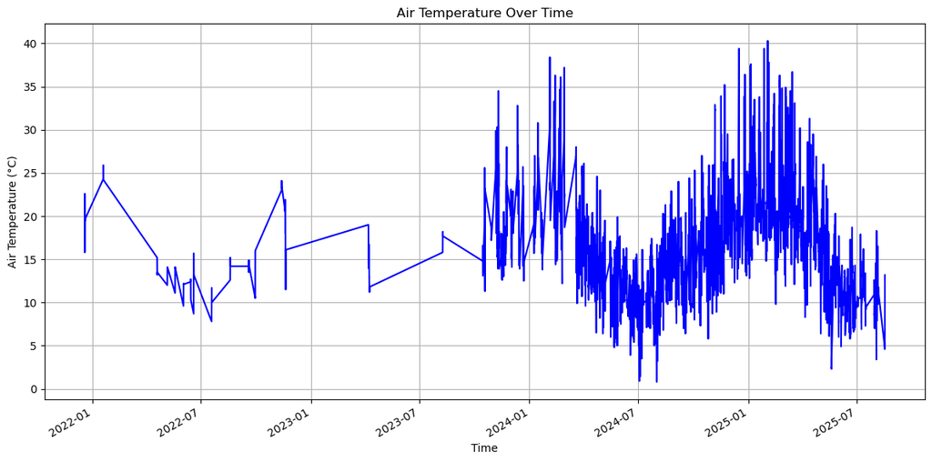

```python
# change time format to be updated
weather_stations_df['time'] = pd.to_datetime(weather_stations_df['time'])

# groupby airtemp by time with average tempreture
temperature_time = weather_stations_df.groupby('time')['airtemp'].mean()

# Visualing a line graph
plt.figure(figsize=(12, 6))
temperature_time.plot(color='blue')

plt.title('Air Temperature Over Time')
plt.xlabel('Time')
plt.ylabel('Air Temperature (°C)')
plt.grid(True)
plt.tight_layout()
plt.show()
```

***Air Temperature Over Time***

Analysing the results obtained, it is clearly that there is less significant data before 2024-01, as the number of data points are quite low, inidcating data collection frequency during this time was lower than expected. However, the general trend of the data seems to be consistent with the higher frequency data, indicating tempreture has increased in summer and decreases in winter.

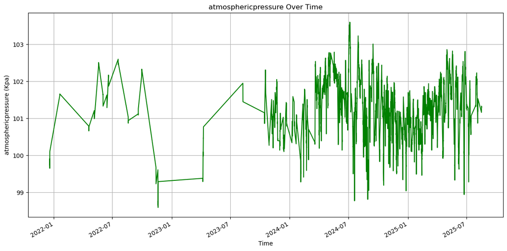

```python
# Convert 'time' to datetime format
weather_stations_df['time'] = pd.to_datetime(weather_stations_df['time'])

# groupby time
temperature_time = weather_stations_df.groupby('time')['atmosphericpressure'].mean()

# Plotting
plt.figure(figsize=(12, 6))
temperature_time.plot(color='green')

plt.title('atmosphericpressure Over Time')
plt.xlabel('Time')
plt.ylabel('atmosphericpressure (Kpa)')
plt.grid(True)
plt.tight_layout()
plt.show()
```

***Atmospheric Pressure Over Time***

Analysing the results obtained, it is clearly that there is less significant data before 2024-01, as the number of data points are quite low, inidcating data collection frequency during this time was lower than expected. However, the general trend of the data seems to be consistent with the more recent data similar to the data represented in Air tempreture.

#### Uniform Date time

```python
pedestrian_hourly = pedestrian_counting.groupby('date_time')['hourday'].sum().reset_index()
pedestrian_hourly.columns = ['date_time', 'pedestrian_count']
```

```python
pedestrian_hourly['date_time'] = pedestrian_hourly['date_time'].dt.tz_localize(None).dt.floor('h')
weather_stations_df['date_time'] = weather_stations_df['date_time'].dt.tz_localize(None).dt.floor('h')
```

### Visualising weather station features against Pedestrian count

All key features are visually examined against pedestrian count, this is done by merging the datasets into the `combined_df`

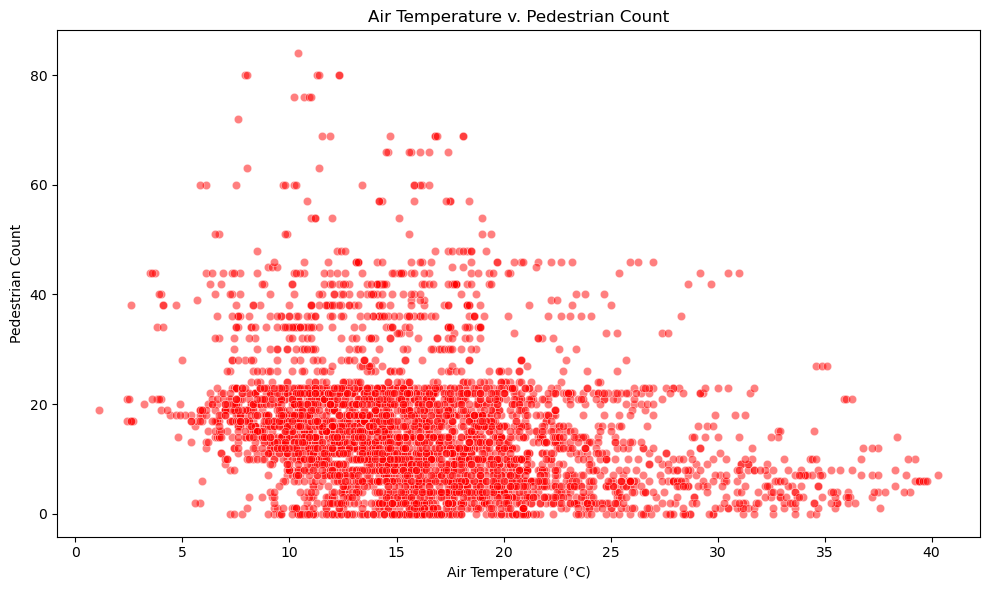

```python
plt.figure(figsize= (12, 10))

#create a combined dataset of pedestrian and weather data merge by date_time
combined_df = pd.merge(pedestrian_hourly, weather_stations_df, on= 'date_time', how= 'inner')

# Scatterplot air temperature vs pedestrian Count
plt.figure(figsize=(10, 6))
sns.scatterplot(data=combined_df, x='airtemp', y='pedestrian_count', alpha=0.5, color = 'red')
plt.title("Air Temperature v. Pedestrian Count")
plt.xlabel("Air Temperature (°C)")
plt.ylabel("Pedestrian Count")
plt.tight_layout()
plt.show()
```

***Air Temperature vs Pedestrian Count***

Analysing the results obtained in the scatterplot, data is grouped around the 10°C and 25°C range. The pedestrian count range is clustered around 0-20, and smaller distribution of higher pedestrian count with the peak count values within 10°C and 25°C range. From this scatterplot, it inidicates that more moderate tempretures result in increased pedestrian activity, with the extreme tempretures, that is less than 5°C and greater than 30°C having a clear negative correlation with pedestrian count. The relationship is indicative of a quadratic relationship as both low and high tempretures have lower pedestrian count values and highest pedestrian count exists within moderate temperature values.

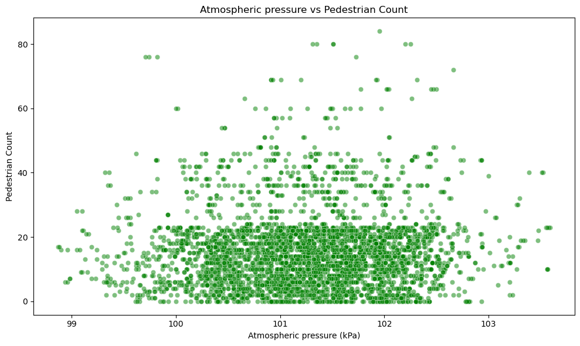

```python
# Scatterplot atmospheric pressue vs pedestrian count
plt.figure(figsize=(10, 6))
sns.scatterplot(data=combined_df, x='atmosphericpressure', y='pedestrian_count', alpha=0.5, color = 'green')
plt.title("Atmospheric pressure vs Pedestrian Count")
plt.xlabel("Atmospheric pressure (kPa)")
plt.ylabel("Pedestrian Count")
plt.tight_layout()
plt.show()
```

***Atmospheric Pressure vs Pedestrian Count***

Analysing the results obtained in the scatterplot for Atmospheric Pressure vs Pedestrian Count, we can see the range is between 99 to 103 kPa. From this data no clear linear relationship can be distinguised. Indicating Atmospheric Pressure alone is not a strong predictor, would be best not to include in the model as it may incorporate noise into the models performance.

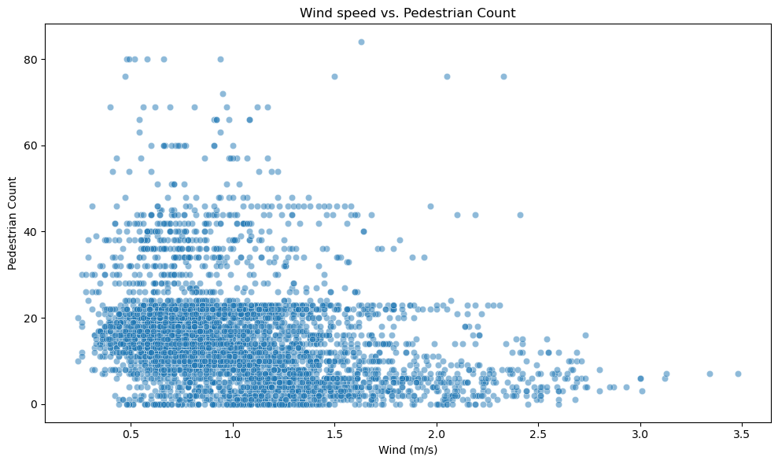

```python
# Scatterplot windspeed vs pedestrian Count
combined_df = combined_df[combined_df['windspeed'] > -100]

plt.figure(figsize=(10, 6))
sns.scatterplot(data=combined_df, x='windspeed', y='pedestrian_count', alpha=0.5)
plt.title("Wind speed vs. Pedestrian Count")
plt.xlabel("Wind (m/s)")
plt.ylabel("Pedestrian Count")
plt.tight_layout()
plt.show()
```

***Wind Speed vs Pedestrian Count***

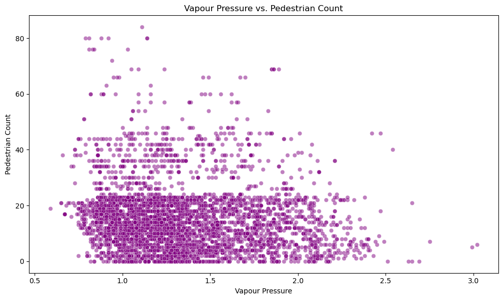

```python
#Scatterplot vapourpressure vs pedestrian count
plt.figure(figsize=(10, 6))
sns.scatterplot(data=combined_df, x='vapourpressure', y='pedestrian_count', alpha=0.5, color = 'purple')
plt.title("Vapour Pressure vs. Pedestrian Count")
plt.xlabel("Vapour Pressure")
plt.ylabel("Pedestrian Count")
plt.tight_layout()
plt.show()
```

***Vapour Pressure vs Pedestrian Count***

Analysing the results obtained in the scatterplot, There does not seem to be a strong relationship between vapour pressure and foot traffic, we do see a slight decrease in foot traffic as vapour pressure increases, indicating less people walk in more humid climates, however, it is not a strong enough correlation on its own may be effective on improving the models performance when combined with another feature.

### Correlation matrix

A correlation matrix is an effective method to represent the linear relationship between features in a dataset. It is an essential tool utlitised in feature engineeringm as it aids in identifying how strongly features are correlated with each other, find features that have strong correlation with the target variable and importantly enable the detection of multicolinearlity in which two features are highly similar and hence may reduce the perfromance of the ML model.

1. Combine the features into a singular dataset. All relavent features are moved into a singular dataset.
2. Implement and visualise the correlation matrix.

```python
combined_data = combined_df.drop(columns=['date_time', 'time', 'command', 'precipitation', 'longitude','latitude'])
```

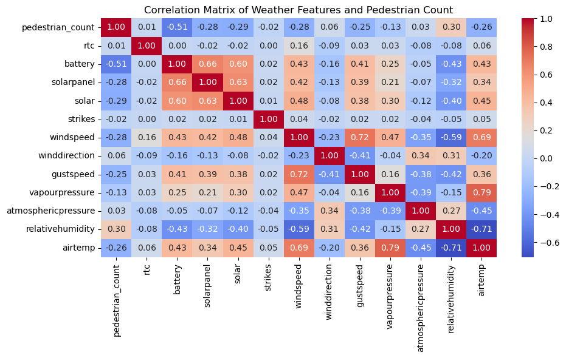

```python
# Coreelation matrix strucutre
c_matrix = combined_data.corr()

# visualisation of the matrix
plt.figure(figsize=(10, 6))
sns.heatmap(c_matrix, annot=True, cmap='coolwarm', fmt=".2f")
plt.title("Correlation Matrix of Weather Features and Pedestrian Count")
plt.tight_layout()
plt.show()
```

***Correlation matrix***

The correlation matrix allows us to determine the linear relationship between two feature pairs by anaysling the values it will allow us to determine, which features have a high correlation with pedestrian count and which features, do not. This will also enable us to determine how similiar featrues are to each other. The values range from 1 to -1, indicating a positive linear relationship between two features, the values -1 is indicative of a negitive linear relationship between the two features. A value of 0 indicates no linear corrleation between the two features or as such the relationship cannot be captured linearly. By imploring the correlation matrix it has enabled a visual representation of how each feature correlates to the the target variable pedestrian count.

**Most Important Features**

#### Data Quality and Summary Statistics Overview Venue data

1. **Missing data Check**
   - I check the total number of missing data within each column with the sue of `.isnull().sum()`, this will indicate if there is missing data and which column does have it.
2. **Statistical Description**
   - To obtain a statistical summary I use the `.describe()` method. This will aid in understanding the distribution of the data and will point out any annomailies.
3. **Data Structure Summary**
   - To obtain a statistical overview of the dataset and find outliers it is useful to implement `.info()`

```python
print("Check for missing information in each column")
print(venue_location.isnull().sum())
print("Statistical Description")
print(venue_location.describe())
print("Data Structure Summary")
print(venue_location.info())
```

```
Check for missing information in each column
geo_point_2d      0
geo_shape         0
prop_id           0
no_smoking        0
level_1_na        0
addresspt1        0
event             0
full_name         0
addressp_1        0
training          0
dog_prohib        0
dog_off_le        0
venue_recn        0
addresspt         0
sport           139
promotion       206
bookable          0
level_3_na      192
wedding           0
roadseg_id        0
sustainabi       18
level_2_na        0
latitude          0
longitude         0
dtype: int64
Statistical Description
         latitude   longitude
count  206.000000  206.000000
mean   -37.810742  144.963473
std      0.017024    0.016949
min    -37.844590  144.913667
25%    -37.821651  144.954027
50%    -37.812328  144.968012
75%    -37.798513  144.976381
max    -37.778101  144.989091
Data Structure Summary
<class 'pandas.core.frame.DataFrame'>
RangeIndex: 206 entries, 0 to 205
Data columns (total 24 columns):
```

[output cut: 14 more lines]

```
 12  venue_recn    206 non-null    object
 13  addresspt     206 non-null    object
 14  sport         67 non-null     object
 15  promotion     0 non-null      object
 16  bookable      206 non-null    object
 17  level_3_na    14 non-null     object
 18  wedding       206 non-null    object
 19  roadseg_id    206 non-null    object
 20  sustainabi    188 non-null    object
 21  level_2_na    206 non-null    object
 22  latitude      206 non-null    float64
 23  longitude     206 non-null    float64
dtypes: float64(2), object(22)
memory usage: 38.8+ KB
None
```

### Converting categorical data to numerical.

The for loop, loops throught the features in the venue_locations dataset. Given the data in the column is catergorical Y or N it will convert the values to the respective 1 and 0. This is important as ML models cannot understand categorical data. It is important to convert them into numerical data.

```python
#converting categorical features in venue location to numerical for Y/N to 1/0
for col in ['event', 'wedding', 'sport', 'bookable', 'dog_prohib','training', 'dog_off_le', 'no_smoking']:
    venue_location[col] = venue_location[col].apply(lambda x: 1 if str(x).strip().upper() == 'Y' else 0)

venue_location.head()
```

|  | geo_point_2d | geo_shape | prop_id | no_smoking | level_1_na | addresspt1 | event | full_name | addressp_1 | training | ... | sport | promotion | bookable | level_3_na | wedding | roadseg_id | sustainabi | level_2_na | latitude | longitude |
| --- | --- | --- | --- | --- | --- | --- | --- | --- | --- | --- | --- | --- | --- | --- | --- | --- | --- | --- | --- | --- | --- |
| 0 | {'lon': 144.98896595113547, 'lat': -37.8171274... | {'type': 'Feature', 'geometry': {'coordinates'... | 0 | 0 | Other Park Locations | 29.98397741 | 1 | Other Park Locations: Weedon Reserve | 77 | 0 | ... | 0 | None | 1 | None | 0 | 21951 | L | Weedon Reserve | -37.817127 | 144.988966 |
| 1 | {'lon': 144.98293613155118, 'lat': -37.8425742... | {'type': 'Feature', 'geometry': {'coordinates'... | 103756 | 0 | Fawkner Park | 0.0 | 0 | Fawkner Park: FP - Cordner_T1_T2_T3_F2_Ct3 | 0 | 0 | ... | 1 | None | 1 | None | 0 | 0 | M | FP - Cordner_T1_T2_T3_F2_Ct3 | -37.842574 | 144.982936 |
| 2 | {'lon': 144.9554621837315, 'lat': -37.78557214... | {'type': 'Feature', 'geometry': {'coordinates'... | 107426 | 0 | Royal Park | 0.0 | 0 | Royal Park: RP - Lawn 6_Walker East_Ct2 | 0 | 0 | ... | 1 | None | 1 | None | 0 | 0 | L | RP - Lawn 6_Walker East_Ct2 | -37.785572 | 144.955462 |
| 3 | {'lon': 144.98286097598913, 'lat': -37.8445902... | {'type': 'Feature', 'geometry': {'coordinates'... | 103756 | 0 | Fawkner Park | 0.0 | 1 | Fawkner Park: FP - Lawn 21_T8_S3 | 0 | 1 | ... | 1 | None | 1 | None | 0 | 0 | M | FP - Lawn 21_T8_S3 | -37.844590 | 144.982861 |
| 4 | {'lon': 144.97660241098285, 'lat': -37.8246014... | {'type': 'Feature', 'geometry': {'coordinates'... | 108615 | 0 | Kings Domain | 0.0 | 1 | Kings Domain: KD - Lawn 9/Pillars of Wisdom | 0 | 1 | ... | 0 | None | 1 | None | 1 | 0 | M | KD - Lawn 9/Pillars of Wisdom | -37.824601 | 144.976602 |

5 rows × 24 columns

### Dropping Unnecessary Columns

To clean the dataset redundant information is dropped the columns dropped are:

- **`geo_point_2d`**:Redundant with latitude and longitude
- **`geo_shape`** :Complex geometry not usable in standard ML pipelines
- **`level_1_na`** unnecessary data
- **`addresspt1`**: Textual address; not informative for ML
- **`addresspt`** unnecessary data
- **`level_3_na`** unnecessary data
- **`roadseg_id`** Categorical ID with no predictive signal unless joined with external dataset
- **`sustainabi`** Has no significance, in capturing pedestrian count
- **`level_2_na`** unnecessary data

```python
print(venue_location.columns)
venue_location.drop(['geo_point_2d','geo_shape', 'level_1_na', 'addresspt1', 'addresspt','level_3_na', 'roadseg_id', 'sustainabi','level_2_na'], axis=1, inplace=True)
venue_location.head()
```

```
Index(['geo_point_2d', 'geo_shape', 'prop_id', 'no_smoking', 'level_1_na',
       'addresspt1', 'event', 'full_name', 'addressp_1', 'training',
       'dog_prohib', 'dog_off_le', 'venue_recn', 'addresspt', 'sport',
       'promotion', 'bookable', 'level_3_na', 'wedding', 'roadseg_id',
       'sustainabi', 'level_2_na', 'latitude', 'longitude'],
      dtype='object')
```

|  | prop_id | no_smoking | event | full_name | addressp_1 | training | dog_prohib | dog_off_le | venue_recn | sport | promotion | bookable | wedding | latitude | longitude |
| --- | --- | --- | --- | --- | --- | --- | --- | --- | --- | --- | --- | --- | --- | --- | --- |
| 0 | 0 | 0 | 1 | Other Park Locations: Weedon Reserve | 77 | 0 | 0 | 0 | 402 | 0 | None | 1 | 0 | -37.817127 | 144.988966 |
| 1 | 103756 | 0 | 0 | Fawkner Park: FP - Cordner_T1_T2_T3_F2_Ct3 | 0 | 0 | 0 | 0 | 1354 | 1 | None | 1 | 0 | -37.842574 | 144.982936 |
| 2 | 107426 | 0 | 0 | Royal Park: RP - Lawn 6_Walker East_Ct2 | 0 | 0 | 0 | 0 | 277 | 1 | None | 1 | 0 | -37.785572 | 144.955462 |
| 3 | 103756 | 0 | 1 | Fawkner Park: FP - Lawn 21_T8_S3 | 0 | 1 | 0 | 1 | 67 | 1 | None | 1 | 0 | -37.844590 | 144.982861 |
| 4 | 108615 | 0 | 1 | Kings Domain: KD - Lawn 9/Pillars of Wisdom | 0 | 1 | 0 | 0 | 184 | 0 | None | 1 | 1 | -37.824601 | 144.976602 |

### Geospatial Visualisation of Venue Location and Pedestrian Sensor location.

This follium graph will represent the visual markers of all of the venue locations across melbourne, this will enable us to see the spread of location venues. The graph also has visual representation of the pedestrian count sensor locations, enabling a clear representation of the the spread of venue and pedestrian sensors and how they correlate. Aiding in better understanding the problem.

```python
import folium
#centre the map on Melbourne
m = folium.Map(location=[-37.8136, 144.9631], zoom_start= 14)
#iterate over the rows in venue location
for _, row in venue_location.iterrows():
    if pd.notnull(row['latitude']) and pd.notnull(row['longitude']):
        folium.CircleMarker(
            location=[row['latitude'], row['longitude']],
            radius=3,
            color='blue',
            fill=True
        ).add_to(m)

for _, row in pedestrian_counting.iterrows():
    if pd.notnull(row['latitude']) and pd.notnull(row['longitude']):
        folium.CircleMarker(
            location=[row['latitude'], row['longitude']],
            radius=3,
            color='yellow',
            fill=True
        ).add_to(m)

# Add legend
legend_html = """
<div style="position: fixed;
            bottom: 50px; left: 50px; width: 150px; height: 100px;
            background-color: rgba(255, 255, 255, 0.8); border:2px solid grey; z-index:1000; font-size:12px;
            padding: 10px;">
<b>Legend</b><br>
<i style="background:blue; width:10px; height:10px; display:inline-block; border-radius:50%;"></i>&nbsp;Venue Location<br>
<i style="background:yellow; width:10px; height:10px; display:inline-block; border-radius:50%;"></i>&nbsp;Pedestrian Counter<br>
</div>
"""
m.get_root().html.add_child(folium.Element(legend_html))
m
```

Make this Notebook Trusted to load map: File -> Trust Notebook

[interactive chart not shown]

### Visualisation Summary of Spatial Data

The output generated is an interactive map of the Melbourne CBD featuring:

- **Yellow dots**: Pedestrian counter
- **Blue dots**: Venue Locations

From the map, several key insights can be drawn:

- Pedestrian sensors are installed only at specific points, which means that pedestrian traffic data is not uniformly available city-wide.
- Venue Locations, tend to surround the city and only few venue location have a sensor within a close distance, this does pose the difficulty of accuratly determining the pedestrian count at the venue locations.
- This limitation inidcates, the necessity to utilise various metrics to capture relationships with pedestrian count and be able to provide a reliable output.
- Visualising this spatial data has proven to be highly informative it provides critical context to the effective design and implementation of the AI pedestrian flow use case.

### Calculating Distance from Venue to Pedestrian count

Utilising GeoPy, which is a python library that makes geographical calculations on distance in this case between the Venue location and each pedestrian sensor, this will be a key feature in determining the pedestrian count at the venue location as the venue lcoation data does not contain pedestrian sensors at the location or historical time data.

```python
from geopy.distance import geodesic
# store the distance values and the other essential features
distance_rows = []
# for loop, loops through each venue in venue location and assigned the value to the name
for _, venue in venue_location.iterrows():
    venue_loc = (venue['latitude'], venue['longitude'])
    venue_id = venue['prop_id']
    venue_name = venue['full_name']
    sport = venue['sport']
    wedding = venue['wedding']
    bookable = venue['bookable']
    no_smoking = venue['no_smoking']
    event = venue['event']
    training = venue['training']
    dog_prohib = venue['dog_prohib']

    # the secondary loop, loops through pedestrian count and caclulates the distance
    for _, sensor in pedestrian_counting.iterrows():
        sensor_loc = (sensor['latitude'], sensor['longitude'])
        sensor_id = sensor['location_id']
        # The distance is calculated using geodesic venue location and sensor locaiton.
        distance = geodesic(venue_loc, sensor_loc).meters
        # the data is then appended to the distance_rows list
        distance_rows.append({'venue_id': venue_id, 'venue_name': venue_name, 'sensor_id': sensor_id, 'distance_venue': distance,
                              'sport': sport, 'wedding': wedding, 'bookable':bookable, 'no_smoking':no_smoking, 'event': event,
                              'training': training, 'dog_prohib': dog_prohib} )
#distance_rows is converted into pandas dataframe and renamed under venue_sensor_distance
venue_sensor_distance = pd.DataFrame(distance_rows)

venue_sensor_distance.head()
```

|  | venue_id | venue_name | sensor_id | distance_venue | sport | wedding | bookable | no_smoking | event | training | dog_prohib |
| --- | --- | --- | --- | --- | --- | --- | --- | --- | --- | --- | --- |
| 0 | 0 | Other Park Locations: Weedon Reserve | 86 | 3841.864082 | 0 | 0 | 1 | 0 | 1 | 0 | 0 |
| 1 | 0 | Other Park Locations: Weedon Reserve | 86 | 3841.864082 | 0 | 0 | 1 | 0 | 1 | 0 | 0 |
| 2 | 0 | Other Park Locations: Weedon Reserve | 24 | 3041.625597 | 0 | 0 | 1 | 0 | 1 | 0 | 0 |
| 3 | 0 | Other Park Locations: Weedon Reserve | 72 | 1782.008421 | 0 | 0 | 1 | 0 | 1 | 0 | 0 |
| 4 | 0 | Other Park Locations: Weedon Reserve | 10 | 3690.259064 | 0 | 0 | 1 | 0 | 1 | 0 | 0 |

The process of calculating the distance to each sensor from the venue has significantly increased the size fo the dataframe, a lot of this information is not relavent as we are only concerned about the resutls obtained by the pedestrian sensor closest to the venue. I will then group the data and only keep the shortest distance from each venue to the closest sensor.

### Nearest Sensor Calculation

The data is grouped by venue id then the shortest distance is calculated utilising `idxmin()`

```python
# Select the row with the minimum distance for each venue_id
nearest_sensors = venue_sensor_distance.loc[venue_sensor_distance.groupby('venue_id')['distance_venue'].idxmin()].reset_index(drop=True)

nearest_sensors.head()
```

|  | venue_id | venue_name | sensor_id | distance_venue | sport | wedding | bookable | no_smoking | event | training | dog_prohib |
| --- | --- | --- | --- | --- | --- | --- | --- | --- | --- | --- | --- |
| 0 | 0 | Promotional Spaces: Melbourne Central Station... | 66 | 62.590427 | 0 | 0 | 1 | 0 | 0 | 0 | 0 |
| 1 | 100385 | Alexandra Gardens: AG - Henley Landing | 136 | 347.445537 | 0 | 0 | 1 | 0 | 1 | 0 | 0 |
| 2 | 100514 | Other Park Locations: North Melbourne Recreat... | 180 | 696.844279 | 0 | 0 | 1 | 0 | 1 | 0 | 0 |
| 3 | 100894 | Other Park Locations: Bayswater Road Park | 85 | 528.924036 | 0 | 0 | 1 | 1 | 1 | 0 | 0 |
| 4 | 101101 | Alexandra Gardens: AG - Lawn2/Peppercorn Lawn | 29 | 60.177471 | 0 | 0 | 1 | 0 | 1 | 1 | 0 |

When analysing the shape of the matrix we can see that it has decreased significantly from the 2059794 rows to 80.

```python
print(pedestrian_counting.columns)
```

```
Index(['location_id', 'sensing_date', 'hourday', 'direction_1', 'direction_2',
       'pedestriancount', 'latitude', 'longitude', 'date_time'],
      dtype='object')
```

### Merging Datasets

The final dataset is created by merging pdestrianc count, nearest_senor(venue data) and weather data. Merge pedestrian count with nearest sensor left on location id and right on sensor id with inner join. Next model_df is merged with weather station data on date_time with inner join. The purpose is to combine all the datasets to extract the key features to be able to apply predicitive models.

```python
# Merge pedestrian count with nearest sensor left on location id and right on sensor id with inner join.
model_df = pd.merge(
    pedestrian_counting,
    nearest_sensors,
    left_on='location_id', right_on='sensor_id',
    how='inner'
)

# model_df is merged with weather station data on date_time with inner join
model_df = pd.merge(
    model_df,
    weather_stations_df,
    on='date_time',
    how='inner'
)

model_df.head()
```

|  | location_id | sensing_date | hourday | direction_1 | direction_2 | pedestriancount | latitude_x | longitude_x | date_time | venue_id | ... | strikes | windspeed | winddirection | gustspeed | vapourpressure | atmosphericpressure | relativehumidity | airtemp | latitude_y | longitude_y |
| --- | --- | --- | --- | --- | --- | --- | --- | --- | --- | --- | --- | --- | --- | --- | --- | --- | --- | --- | --- | --- | --- |
| 0 | 130 | 2025-03-03 | 14 | 47 | 32 | 79 | -37.820464 | 144.941268 | 2025-03-03 14:00:00 | 604120 | ... | 0 | 0.93 | 181.5 | 2.41 | 1.34 | 101.60 | 77 | 15.4 | None | None |
| 1 | 130 | 2025-03-03 | 14 | 47 | 32 | 79 | -37.820464 | 144.941268 | 2025-03-03 14:00:00 | 611697 | ... | 0 | 0.93 | 181.5 | 2.41 | 1.34 | 101.60 | 77 | 15.4 | None | None |
| 2 | 130 | 2025-03-03 | 14 | 47 | 32 | 79 | -37.820464 | 144.941268 | 2025-03-03 14:00:00 | 651910 | ... | 0 | 0.93 | 181.5 | 2.41 | 1.34 | 101.60 | 77 | 15.4 | None | None |
| 3 | 130 | 2025-03-05 | 10 | 58 | 22 | 80 | -37.820464 | 144.941268 | 2025-03-05 10:00:00 | 604120 | ... | 0 | 1.30 | 154.4 | 3.01 | 2.06 | 101.69 | 86 | 20.4 | None | None |
| 4 | 130 | 2025-03-05 | 10 | 58 | 22 | 80 | -37.820464 | 144.941268 | 2025-03-05 10:00:00 | 604120 | ... | 0 | 1.23 | 148.7 | 2.93 | 2.07 | 101.68 | 86 | 20.5 | None | None |

5 rows × 37 columns

### Cleaning Model_df

This process, is the final removal of all features that do not provide any valuable insight into prediciting pedestrian count. It removes unecessary data and cleans the dataset.

```python
model_df.drop(['direction_1','direction_2', 'rtc', 'solarpanel', 'command', 'solar', 'precipitation', 'strikes', 'time','latitude_x', 'longitude_x', 'latitude_y', 'longitude_y', 'sensor_id', 'venue_name'  ], axis = 1, inplace=True)
model_df.head()
```

|  | location_id | sensing_date | hourday | pedestriancount | date_time | venue_id | distance_venue | sport | wedding | bookable | ... | training | dog_prohib | battery | windspeed | winddirection | gustspeed | vapourpressure | atmosphericpressure | relativehumidity | airtemp |
| --- | --- | --- | --- | --- | --- | --- | --- | --- | --- | --- | --- | --- | --- | --- | --- | --- | --- | --- | --- | --- | --- |
| 0 | 130 | 2025-03-03 | 14 | 79 | 2025-03-03 14:00:00 | 604120 | 197.215163 | 0 | 0 | 1 | ... | 0 | 0 | 4.172 | 0.93 | 181.5 | 2.41 | 1.34 | 101.60 | 77 | 15.4 |
| 1 | 130 | 2025-03-03 | 14 | 79 | 2025-03-03 14:00:00 | 611697 | 332.649732 | 0 | 0 | 1 | ... | 0 | 0 | 4.172 | 0.93 | 181.5 | 2.41 | 1.34 | 101.60 | 77 | 15.4 |
| 2 | 130 | 2025-03-03 | 14 | 79 | 2025-03-03 14:00:00 | 651910 | 49.092892 | 0 | 0 | 1 | ... | 0 | 0 | 4.172 | 0.93 | 181.5 | 2.41 | 1.34 | 101.60 | 77 | 15.4 |
| 3 | 130 | 2025-03-05 | 10 | 80 | 2025-03-05 10:00:00 | 604120 | 197.215163 | 0 | 0 | 1 | ... | 0 | 0 | 4.183 | 1.30 | 154.4 | 3.01 | 2.06 | 101.69 | 86 | 20.4 |
| 4 | 130 | 2025-03-05 | 10 | 80 | 2025-03-05 10:00:00 | 604120 | 197.215163 | 0 | 0 | 1 | ... | 0 | 0 | 4.184 | 1.23 | 148.7 | 2.93 | 2.07 | 101.68 | 86 | 20.5 |

5 rows × 22 columns

### Incorporating day of week

Given the impact that date and time have on pedestrian count as seen earlier, `day_of_week` feature will train the model on this relationship and help improve the accuracy of the model.

```python
model_df['day_of_week'] = model_df['sensing_date'].dt.dayofweek
```

```python
print(model_df.columns)
```

```
Index(['location_id', 'sensing_date', 'hourday', 'pedestriancount',
       'date_time', 'venue_id', 'distance_venue', 'sport', 'wedding',
       'bookable', 'no_smoking', 'event', 'training', 'dog_prohib', 'battery',
       'windspeed', 'winddirection', 'gustspeed', 'vapourpressure',
       'atmosphericpressure', 'relativehumidity', 'airtemp', 'day_of_week'],
      dtype='object')
```

```python
model_df.head()
```

|  | location_id | sensing_date | hourday | pedestriancount | date_time | venue_id | distance_venue | sport | wedding | bookable | ... | dog_prohib | battery | windspeed | winddirection | gustspeed | vapourpressure | atmosphericpressure | relativehumidity | airtemp | day_of_week |
| --- | --- | --- | --- | --- | --- | --- | --- | --- | --- | --- | --- | --- | --- | --- | --- | --- | --- | --- | --- | --- | --- |
| 0 | 130 | 2025-03-03 | 14 | 79 | 2025-03-03 14:00:00 | 604120 | 197.215163 | 0 | 0 | 1 | ... | 0 | 4.172 | 0.93 | 181.5 | 2.41 | 1.34 | 101.60 | 77 | 15.4 | 0 |
| 1 | 130 | 2025-03-03 | 14 | 79 | 2025-03-03 14:00:00 | 611697 | 332.649732 | 0 | 0 | 1 | ... | 0 | 4.172 | 0.93 | 181.5 | 2.41 | 1.34 | 101.60 | 77 | 15.4 | 0 |
| 2 | 130 | 2025-03-03 | 14 | 79 | 2025-03-03 14:00:00 | 651910 | 49.092892 | 0 | 0 | 1 | ... | 0 | 4.172 | 0.93 | 181.5 | 2.41 | 1.34 | 101.60 | 77 | 15.4 | 0 |
| 3 | 130 | 2025-03-05 | 10 | 80 | 2025-03-05 10:00:00 | 604120 | 197.215163 | 0 | 0 | 1 | ... | 0 | 4.183 | 1.30 | 154.4 | 3.01 | 2.06 | 101.69 | 86 | 20.4 | 2 |
| 4 | 130 | 2025-03-05 | 10 | 80 | 2025-03-05 10:00:00 | 604120 | 197.215163 | 0 | 0 | 1 | ... | 0 | 4.184 | 1.23 | 148.7 | 2.93 | 2.07 | 101.68 | 86 | 20.5 | 2 |

5 rows × 23 columns

## Machine Learning Model

After the dataset have been unified and all the key features are extrated into the final dataset, the last step is to apply the Machine Learning model. In this instance, I have applied multiple, multiple ML models to assess the performance in with the use of various ML models.

### Feature Selection

Preparing to apply the ML model we need to select the final features that will be utilised, and select the target variable. The Features are maintained in a list with all the features, the target variable is selected in which case the goal is to identify the pedestrian count at the provided location.

```python
from sklearn.model_selection import train_test_split
import sklearn.preprocessing as preproc
from sklearn.ensemble import RandomForestRegressor

#Features is a list of all the features that the ML model will be trained on
features = [
    'distance_venue','sport','wedding','bookable','no_smoking', 'event','training','dog_prohib',
    'battery','windspeed','winddirection','gustspeed','vapourpressure','atmosphericpressure','relativehumidity',
    'airtemp','day_of_week'
]
#The X variable is the features
X = model_df[features]
# The y variable is the target variable
y = model_df['pedestriancount']
```

### Polynomial Features

I have implemented pairwise interaction features, this process is utilised in predictive modelling as the combined effect of two features is different than the individual features. This will allow me to capture relationships between features that are of a higher degree and allows for the model to better predict the target variable, provided there are sufficient sample.

```python
# pairwise interaction features
X2 = preproc.PolynomialFeatures(degree=2,include_bias=False).fit_transform(X)
# Output the shape of the transformed features
print(X2.shape)
```

```
(4707, 170)
```

We can see that, the features have significantly increased within the dataset, we have gone from the inital 17 features, to the final 170 features after pairwise interaction features have been applied.

### Train Test Split

In this process the dataset is split into two parts the training set which is implemented to train the model and the testing set, which is data that model has not seen to be able to test the performance against. In this case the test_size is 0.2 indicating 80% of the data will be utilised in training and 20% will be utilised in testing.

```python
X1_train, X1_test, y_train, y_test = train_test_split(X, y,test_size=0.2, random_state=123)
X2_train, X2_test, _, _ = train_test_split(X2, y, test_size=0.2,random_state=123)
```

### Applying Linear Regression Model

-1) The Linear Regression Model is applied to the initial feature set. The model is trained on the original dataset and will utilise `X1_train`. Once the model is trained using `linear_r_model.fit()`, the model will then make predictions using `linear_r_model.predict(X1_test)`. The performance of the model is finally determined by root mean squared error and R^2 Score.

-2) The Linear Regression Model is applied to the interaction feature set. The model is trained on the interaction features X2 and will utilise `X2_train`. Once the model is trained using `linear_r_model.fit()`, the model will then make predictions using `linear_r_model.predict(X2_test)`. The performance of the model is finally determined by root mean squared error and R^2 Score.

```python
from sklearn.linear_model import LinearRegression
from sklearn.metrics import root_mean_squared_error, r2_score

# Instantiate Linear regression model
linear_r_model = LinearRegression()
# Train the model on original features X1
linear_r_model.fit(X1_train, y_train)
# From the trained model predictions can be made
y_pred = linear_r_model.predict(X1_test)
# Root mean squared error is utilised to evaluate the perfromance of the model.
print("RMSE:", root_mean_squared_error(y_test, y_pred))
# R^2 score is another method ultised to evaluate the perfomance of the model.
print("R² Score:", r2_score(y_test, y_pred))
```

```
RMSE: 470.3250843207092
R² Score: 0.21154484393837447
```

```python
from sklearn.linear_model import LinearRegression
from sklearn.metrics import root_mean_squared_error, r2_score

# Instantiate Linear regression model
linear_r_model = LinearRegression()
# Train the model on interaction features X2
linear_r_model.fit(X2_train, y_train)
# From the trained model predictions can be made
y_pred = linear_r_model.predict(X2_test)
# Root mean squared error is utilised to evaluate the perfromance of the model.
print("RMSE:", root_mean_squared_error(y_test, y_pred))
# R^2 score is another method ultised to evaluate the perfomance of the model.
print("R² Score:", r2_score(y_test, y_pred))
```

```
RMSE: 414.47537844617756
R² Score: 0.3876803635445494
```

Root Mean Squared Error (RMSE), value of 414.5, indicating the models predicitions are on average 414.5 counts of the original pedestrian count. This value is quite far off and is a slight improvement from the standard features. The RMSE value shouldnt be taken as prime indicator, as many of the venue locations that are predicted do not have pedestrian count sensors located. It can still be utilised as a tool to measure and understand the performance of the model. With that said the RMSE value is still quite high and the interaction features were only able to improve the RMSE slightly from the standard features.

The results obtained R² Score: 0.38, The results obtained still indicate the model doesnt explain much of the varience, however the perfromance has drastically improved from the standard features. With the interaction features the model was effectively explain double the variance and is a signficant improvment.

The linear regression model with the interaction features, has been able to expalin almost double the variance that has existed in the data, but the RMSE score has only marginally improved in this case.

### Applying RandomForest Regression Model

-1) The RF Regression Model is applied to the initial feature set. The model is trained on the original dataset and will utilise `X1_train`. Once the model is trained using `RF_model.fit()`, the model will then make predictions using `RF_model.predict(X1_test)`. The performance of the model if finally determined by root mean squared error and R^2 Score.

-2) The RF Regression Model is then applied to the interaction feature set. The model is trained on the interaction features X2 and will utilise `X2_train`. Once the model is trained using `RF_model.fit()`, the model will then make predictions using `RF_model.predict(X2_test)`. The performance of the model if finally determined by root mean squared error and R^2 Score.

This will allow a comparison with the standard features and the interaction features to determine how the performance of the model is affected

```python
from sklearn.ensemble import RandomForestRegressor

# Instantiate RF Regressor model
RF_model1 = RandomForestRegressor(random_state=42)
# Train the model on original features X1
RF_model1.fit(X1_train, y_train)
# From the trained model predictions can be made
y_pred1 = RF_model1.predict(X1_test)
# Root mean squared error is utilised to evaluate the perfromance of the model.
print("RMSE:", root_mean_squared_error(y_test, y_pred1))
# R^2 score is another method ultised to evaluate the perfomance of the model.
print("R² Score:", r2_score(y_test, y_pred1))
```

```
RMSE: 232.55353797737882
R² Score: 0.8072356955112175
```

#### Random Forest Regression Original Feature Analysis

Random Forest Regression is an ensemble learning method which combines predicitions from multiple decision trees to produce more accurate values. The choice of regression model comes as the model is used for good performance and inparticular the ability to handle complex non-linear relationships. This is a key factor in the decision to utilise the Random Forest model.

The results obtained R² Score: 0.81, The results obtained indicate good fit, especially with the lack of venue time and attendance data. The model can explain most of the varience, and is a signficant increase in performance from the linear regression model in both standard and interaction features.

The Random Forest regression model with standard features, has been able to expalin more than double the variance that has existed in the data in both performance metrics when compared to the linear regression model.

```python
# Instantiate RF Regressor model
RF_model2 = RandomForestRegressor(random_state=42)
# Train the model on original features X1
RF_model2.fit(X2_train, y_train)
# From the trained model predictions can be made
y_pred2 = RF_model2.predict(X2_test)
# Root mean squared error is utilised to evaluate the perfromance of the model.
print("RMSE:", root_mean_squared_error(y_test, y_pred2))
# R^2 score is another method ultised to evaluate the perfomance of the model.
print("R² Score:", r2_score(y_test, y_pred2))
```

```
RMSE: 235.5909624006447
R² Score: 0.8021673510884505
```

#### Random Forest Regression Interaction Feature Analysis

The results obtained R² Score: 0.80, The results obtained indicate good fit, especially with the lack of venue time and attendance data. The model can explain most of the varience, and is a signficant increase in performance from the linear regression model in both standard and interaction features. When comparing the results obtained in the interaction feature, we see there is a marginal decrease in performance, similar to that of RMSE.

The Random Forest regression model with interaction features, has been able to expalin more than double the variance in comparison to the Linear regression model for both cases. However, the performance of the interaction features has decreased marginally from that of the standard features, indicating with the random forest model, it is better to utilise the standard features to predict.

## Conclusion: AI Pedestrian Flow Prediction

The AI Pedestrian Flow Prediciton provides a data driven, solution to be able to determine pedestrian traffic at provided location venues, throughout the city. By combining multiple datasets from the Melbourne Open data portal I was able to capture the relationship between many of the features and pedestrian count to effectively predict the pedestrian traffic at the particular venue.

Throught the feautre engineering process, I utilised many methods to understand and capture the relationship between the pedestrian count and the features. In particular in weather data, utilising the data provided I was able to capture the relationship that existed between different weather metrics. Unforturnatley I was not able to utilise the precipitation data, as the data provided did not have any values associated. I attempted to mitagate this by utilise metrics such as atmospheric pressure, vapour pressure, humidity and airtempreture as rainfall can be predicited with these features. Time of day was also a significant indicator of the pedestrian flow, with this information I incorporated features such as day of week, which would help the model determine further relationships between the days and foot traffic present. As in the real world pedestrian traffic varies day to day and more signifantly varies from weekday and weekend, this relationship was important to capture and played an important role in the pefromance obtained.

Once I was able to determine which features where strong predictors, I was able to merge all of the key features into the model df and apply predicitive models. As seen above the Random Forest Regression model with the standard features outperformed all the other models in particular the Linear regression model. The present limitation were in the venue dataset, as it had a number of missing values, as well as the lack of historical data, such as times that venues are booked, what type of booking is made and the attendence. With this additional data, it will greatly improve the performance of the model and can be used with confidence when planning or determining foot traffic at specific venues.

The model serves as a ultility for city planners, to be able to accuractly determine the predicted pedestrian traffic at any venue location within the city. This information is crucial in providing insight for city planners and emergency services to manage pedestrian movment to reduce overcrowding.